# Flight Landing Distance Analysis

For binary response using Logistic Regression

Vidhi Rathod

13 February 2020

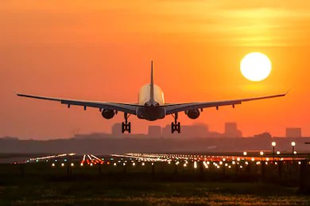

# Landing Assessment

## 1.0 Case Overview:

From now on, we work on the cleaned FAA data set prepared by carrying out the prior project using Linear regression. For other readers I am including the data load part again:

Here,We use same FAA data to predict two types of landings: Risky and long

**Factors Affecting Actual Landing Distance**

**Variable dictionary:**

- Aircraft: The make of an aircraft (Boeing or Airbus).
- Duration (in minutes): Flight duration between taking off and landing. The duration of a normal flight should always be greater than 40min.
- No_pasg: The number of passengers in a flight.
- Speed_ground (in miles per hour): The ground speed of an aircraft when passing over the threshold of the runway. If its value is less than 30MPH or greater than 140MPH, then the landing would be considered as abnormal.
- Speed_air (in miles per hour): The air speed of an aircraft when passing over the threshold of the runway. If its value is less than 30MPH or greater than 140MPH, then the landing would be considered as abnormal.
- Height (in meters): The height of an aircraft when it is passing over the threshold of the runway. The landing aircraft is required to be at least 6 meters high at the threshold of the runway.
- Pitch (in degrees): Pitch angle of an aircraft when it is passing over the threshold of the runway.
- Distance (in feet): The landing distance of an aircraft. More specifically, it refers to the distance between the threshold of the runway and the point where the aircraft can be fully stopped. The length of the airport runway is typically less than 6000 feet.

## 2.1 Initial Set Up

### 2.2 Package Loading

**Required Packages**

- Tidyverse (dplyr, ggplot2..) - Data Read, Manipulation and visualisation
- Plotly - Interactive Visualization
- KableExtra - Styling for table (Styling Data Tables within Markdown)
- gridExtra- Graphical arrangement
- forecast- Time series and forecasting
- ggplot2- Graphical representation
- stringr- string manipulations
- corrplot-making correlogram
- knitrr- Dynamic report generation

### 2.3 Data Loading

**Data Load**

```r
# Read the sheets, one by one
FAA1 <- read_excel("FAA1.xls")
FAA2 <- read_excel("FAA2.xls")
dim(FAA1)
```

```
## [1] 800   8
```

```r
dim(FAA2)
```

```
## [1] 150   7
```

**Structure**

```r
str(FAA1)
```

```
## Classes 'tbl_df', 'tbl' and 'data.frame':    800 obs. of  8 variables:
##  $ aircraft    : chr  "boeing" "boeing" "boeing" "boeing" ...
##  $ duration    : num  98.5 125.7 112 196.8 90.1 ...
##  $ no_pasg     : num  53 69 61 56 70 55 54 57 61 56 ...
##  $ speed_ground: num  107.9 101.7 71.1 85.8 59.9 ...
##  $ speed_air   : num  109 103 NA NA NA ...
##  $ height      : num  27.4 27.8 18.6 30.7 32.4 ...
##  $ pitch       : num  4.04 4.12 4.43 3.88 4.03 ...
##  $ distance    : num  3370 2988 1145 1664 1050 ...
```

```r
str(FAA2)
```

```
## Classes 'tbl_df', 'tbl' and 'data.frame':    150 obs. of  7 variables:
##  $ aircraft    : chr  "boeing" "boeing" "boeing" "boeing" ...
##  $ no_pasg     : num  53 69 61 56 70 55 54 57 61 56 ...
##  $ speed_ground: num  107.9 101.7 71.1 85.8 59.9 ...
##  $ speed_air   : num  109 103 NA NA NA ...
##  $ height      : num  27.4 27.8 18.6 30.7 32.4 ...
##  $ pitch       : num  4.04 4.12 4.43 3.88 4.03 ...
##  $ distance    : num  3370 2988 1145 1664 1050 ...
```

- FAA1 : 800 Rows and 8 columns , sample size is 800 rows
- FAA2 : 150 Rows and 7 columns ,sample size is 150 rows
- FAA2 does not have duration column
- FAA1 AND FAA2 have similar structure, datatypes.

### 4.4 Initial Data processing

In order to combine the 2 data sets we need to make the sructure of both same, by structure we refer to columns.Hence we need to add a column duration to FAA2 and then use rbind function to find 150 +800 =950 rows sample size=950

**Data Merge**

Merge the 2 data sets FAA1 & 2 to create a composite dataset

```r
FAA2$duration<-NA
FAA_merge<-rbind(FAA1,FAA2)
```

**Duplicate Check:** Because the FAA2 has NA in duration column , we need to check for duplicates rows excluding that column. We need to remove the duplicate rows if we find any to reduce redundancy

```r
row_dup<-duplicated(FAA_merge[,-2])
class(row_dup)
```

```
## [1] "logical"
```

```r
FAA_U<-FAA_merge[!row_dup,]
dim(FAA_U)
```

```
## [1] 850   8
```

**Summary Statistics**

we find 850 unique rows and 8 columns. Below is the summary statistics of each column in dataset

```r
dim(FAA_U)
```

```
## [1] 850   8
```

```r
str(FAA_U)
```

```
## Classes 'tbl_df', 'tbl' and 'data.frame':    850 obs. of  8 variables:
##  $ aircraft    : chr  "boeing" "boeing" "boeing" "boeing" ...
##  $ duration    : num  98.5 125.7 112 196.8 90.1 ...
##  $ no_pasg     : num  53 69 61 56 70 55 54 57 61 56 ...
##  $ speed_ground: num  107.9 101.7 71.1 85.8 59.9 ...
##  $ speed_air   : num  109 103 NA NA NA ...
##  $ height      : num  27.4 27.8 18.6 30.7 32.4 ...
##  $ pitch       : num  4.04 4.12 4.43 3.88 4.03 ...
##  $ distance    : num  3370 2988 1145 1664 1050 ...
```

```r
summary(FAA_U)
```

```
##    aircraft            duration         no_pasg      speed_ground
##  Length:850         Min.   : 14.76   Min.   :29.0   Min.   : 27.74
##  Class :character   1st Qu.:119.49   1st Qu.:55.0   1st Qu.: 65.90
##  Mode  :character   Median :153.95   Median :60.0   Median : 79.64
##                     Mean   :154.01   Mean   :60.1   Mean   : 79.45
##                     3rd Qu.:188.91   3rd Qu.:65.0   3rd Qu.: 92.06
##                     Max.   :305.62   Max.   :87.0   Max.   :141.22
##                     NA's   :50
##    speed_air          height           pitch          distance
##  Min.   : 90.00   Min.   :-3.546   Min.   :2.284   Min.   :  34.08
##  1st Qu.: 96.25   1st Qu.:23.314   1st Qu.:3.642   1st Qu.: 883.79
##  Median :101.15   Median :30.093   Median :4.008   Median :1258.09
##  Mean   :103.80   Mean   :30.144   Mean   :4.009   Mean   :1526.02
##  3rd Qu.:109.40   3rd Qu.:36.993   3rd Qu.:4.377   3rd Qu.:1936.95
##  Max.   :141.72   Max.   :59.946   Max.   :5.927   Max.   :6533.05
##  NA's   :642
```

INSIGHTS:

- Duration column in FAA2 file is missing
- Speed air column has 642 NA Values
- duration,distance and height columns have considerable difference between Minimum and Maximum value
- height column has a negative value, which cannot be legit because height is bound to be positive.Hence it can be a data reading issue.

## 3.0 Data Cleaning

### 3.1 Initial scrub

As first steps in Data cleaning we need to filter the rows that do not qualify for data analysis.The are 2 major categories of such line items: * Abnormal values: We need to remove abnormal values(values that do not qualify for analysis, as suggested by SMEs).Below code removes them * NA Rows: We need to remove NA rows(where all cell values are NA).

```r
FAA_U<-FAA_U[FAA_U$duration>=40,]
FAA_U<-FAA_U[FAA_U$speed_ground>=30 && FAA_U$speed_ground<=140,]
FAA_U<-FAA_U[FAA_U$height>=6,]
FAA_U<-FAA_U[FAA_U$distance<=6000,]
nrow(FAA_U)
```

```
## [1] 833
```

```r
sum(is.na(FAA_U$duration))
```

```
## [1] 50
```

```r
sum(is.na(FAA_U$duration))
```

```
## [1] 50
```

```r
sum(is.na(FAA_U$speed_ground))
```

```
## [1] 50
```

```r
sum(is.na(FAA_U$height))
```

```
## [1] 50
```

```r
sum(is.na(FAA_U$distance))
```

```
## [1] 50
```

```r
#Remove all rowa that have NA in all the columns
FAA_U_RmvNA<-FAA_U %>% filter(!(is.na(aircraft)&is.na(duration)&is.na(no_pasg)&is.na(speed_ground)&is.na(speed_air)&is.na(height)&is.na(pitch)&is.na(distance)))
#Looking for NA Values in columns

colSums(is.na(FAA_U_RmvNA))
```

```
##     aircraft     duration      no_pasg speed_ground    speed_air
##            0            0            0            0          588
##       height        pitch     distance
##            0            0            0
```

- Conclusion: we removed close to 850 -783= 67 rows, ** Abnormal values: 17 ** NA VALUE Rows: 50

### 3.2 Binary Response

**Modeling a binary response using logistic regression** **Step 01**

Create two binary variables below and attach them to your data set.

long.landing = 1 if distance > 2500; =0 otherwise risky.landing = 1 if distance > 3000; =0 otherwise.

Discard the continuous data you have for “distance”, and assume we are given the binary data of “long.landing” and “risky.landing” only.

Use above formula to create 2 new columns

```r
FAA_U_RmvNA$long.landing<-ifelse(FAA_U_RmvNA$distance>=2500,1,0)
FAA_U_RmvNA$risky.landing<-ifelse(FAA_U_RmvNA$distance>=3000,1,0)
```

We will not be using the distance variable going forward

## 4.0 Data Analysis

### 4.1 Long Landing

**Univariate analysis**

**STEP2**

*Identifying important factors using the binary data of “long.landing”.*

Use a pie chart or a histogram to show the distribution of “long.landing”.

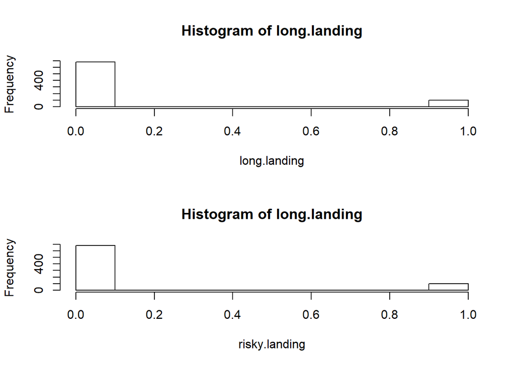

```r
  par(mfrow=c(2,1))
  hist(FAA_U_RmvNA$long.landing,main = paste("Histogram of long.landing"),xlab="long.landing")

#Univariate analysis:risky.landing
  hist(FAA_U_RmvNA$long.landing,main = paste("Histogram of long.landing"),xlab="risky.landing")
```

**Step 3** * Perform single-factor regression analysis for each of the potential risk factors, in a similar way to what you did in Steps 13-15 of Part 1. But here the response “long.landing” is binary. You may consider using logistic regression. Provide a table that ranks the factors from the most important to the least. This table contains 5 columns: **the names of variables, the size of the regression coefficient, the odds ratio, the direction of the regression coefficient (positive or negative), and the p-value.**

```r
#names(FAA_U_RmvNA)
FAAlog<-FAA_U_RmvNA[,-8]
### A model with all variables available
lmod.aircraft<-glm(long.landing~aircraft,family=binomial,FAAlog)
lmod.duration<-glm(long.landing~duration,family=binomial,FAAlog)
lmod.no_pasg<-glm(long.landing~no_pasg,family=binomial,FAAlog)
lmod.speed_ground<-glm(long.landing~speed_ground,family=binomial,FAAlog)
lmod.speed_air<-glm(long.landing~speed_air,family=binomial,FAAlog)
lmod.height<-glm(long.landing~height,family=binomial,FAAlog)
lmod.pitch<-glm(long.landing~pitch,family=binomial,FAAlog)

v1<-c('aircraft',round(coef(lmod.aircraft)[1],2),coef(lmod.aircraft)[2],exp(coef(lmod.aircraft))[1],exp(coef(lmod.aircraft))[2],
     sign<-ifelse(coef(lmod.aircraft)[2]==-1,"Negative","Positive"),coef(summary(lmod.aircraft))[,4])
v2<-c('duration',coef(lmod.duration)[1],coef(lmod.duration)[2],exp(coef(lmod.duration))[1],exp(coef(lmod.duration))[2],
     sign<-ifelse(coef(lmod.duration)[2]==-1,"Negative","Positive"),coef(summary(lmod.duration))[,4])
v3<-c('no_pasg',coef(lmod.no_pasg)[1],coef(lmod.no_pasg)[2],exp(coef(lmod.no_pasg))[1],exp(coef(lmod.no_pasg))[2],
      sign<-ifelse(sign(coef(lmod.no_pasg)[2])==-1,"Negative","Positive"),coef(summary(lmod.no_pasg))[,4])
v4<-c('speed_ground',coef(lmod.speed_ground)[1],coef(lmod.speed_ground)[2],exp(coef(lmod.speed_ground))[1],exp(coef(lmod.speed_ground))[2],
      sign<-ifelse(coef(lmod.speed_ground)[2]==-1,"Negative","Positive"),coef(summary(lmod.speed_ground))[,4])
v5<-c('speed_air',coef(lmod.speed_air)[1],coef(lmod.speed_air)[2],exp(coef(lmod.speed_air))[1],exp(coef(lmod.speed_air))[2],
      sign<-ifelse(coef(lmod.speed_air)[2]==-1,"Negative","Positive"),coef(summary(lmod.speed_air))[,4])
v6<-c('height',coef(lmod.height)[1],coef(lmod.height)[2],exp(coef(lmod.height))[1],exp(coef(lmod.height))[2],
      sign<-ifelse(coef(lmod.height)[2]==-1,"Negative","Positive"),coef(summary(lmod.height))[,4])
v7<-c('pitch',coef(lmod.pitch)[1],coef(lmod.pitch)[2],exp(coef(lmod.pitch))[1],exp(coef(lmod.pitch))[2],
      sign<-ifelse(coef(lmod.pitch)[2]==-1,"Negative","Positive"),coef(summary(lmod.pitch))[,4])

d<-data.frame(rbind(v1,v2,v3,v4,v5,v6,v7))
colnames(d)<-c('Name','B0','B1','OddsRto_B0','OddsRto_B1','Sign','Pvalue_B0','Pvalue_B1')
d$B0<-round(as.numeric(as.character(d$B0)),2)
d$B1<-round(as.numeric(as.character(d$B1)),2)
d$OddsRto_B0<-round(as.numeric(as.character(d$OddsRto_B0)),2)
d$OddsRto_B1<-round(as.numeric(as.character(d$OddsRto_B1)),2)
d$Pvalue_B0<-as.numeric(as.character(d$Pvalue_B0))
d$Pvalue_B1<-as.numeric(as.character(d$Pvalue_B1))
d<-arrange(d,Pvalue_B1,Pvalue_B0)
d$signif<-ifelse(d$Pvalue_B1<0.05,'S','I')
d[,c(1,2,3,6,7,8,9)]
```

```
##           Name     B0    B1     Sign    Pvalue_B0    Pvalue_B1 signif
## 1 speed_ground -48.30  0.48 Positive 7.492101e-14 1.296677e-13      S
## 2    speed_air -52.89  0.52 Positive 1.187237e-10 1.514441e-10      S
## 3     aircraft  -2.39  0.82 Positive 1.592773e-39 2.743033e-04      S
## 4        pitch  -3.25  0.33 Positive 1.277356e-04 1.107887e-01      I
## 5       height  -2.14  0.01 Positive 1.846205e-09 5.128363e-01      I
## 6     duration  -1.75  0.00 Positive 9.116182e-07 6.213848e-01      I
## 7      no_pasg  -1.53 -0.01 Negative 7.471448e-02 6.438361e-01      I
```

**Observation:**

**Step 4.** For those significant factors identified in Step 3, visualize its association with “long.landing”.

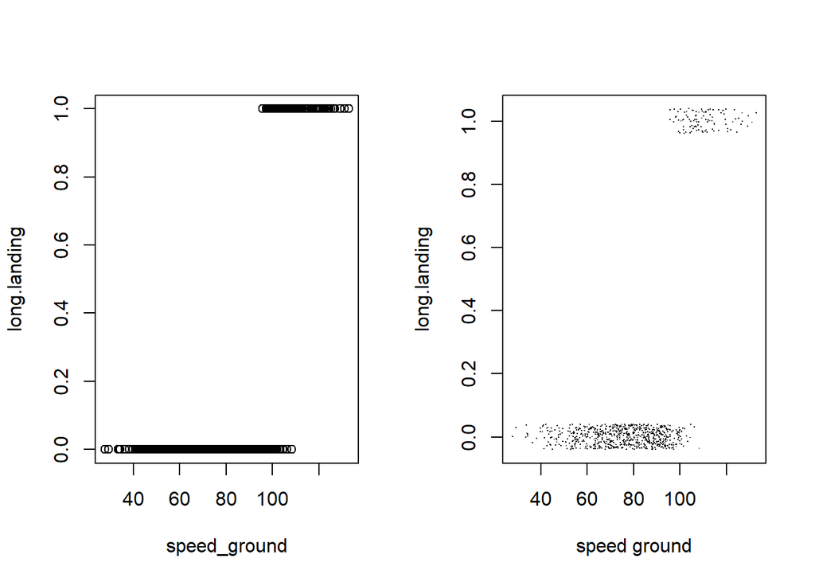

```r
FAAlog$aircraft1<-ifelse(FAAlog$aircraft=='boeing',as.numeric(1),as.numeric(0))
par(mfrow=c(1,2))
plot(long.landing~speed_ground,FAAlog)
plot(jitter(long.landing,0.2)~jitter(speed_ground),FAAlog,xlab ="speed ground",ylab ="long.landing",pch=".")
```

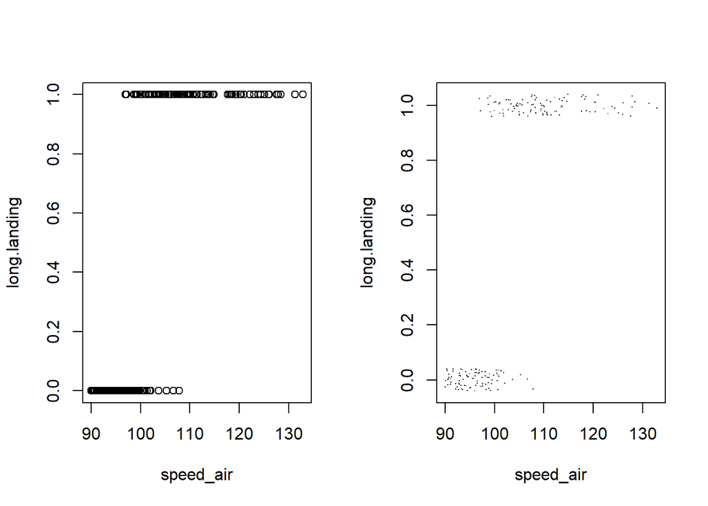

```r
par(mfrow=c(1,2))
plot(long.landing~speed_air,FAAlog)
plot(jitter(long.landing,0.2)~jitter(speed_air),FAAlog,xlab ="speed_air",ylab ="long.landing",pch=".")
```

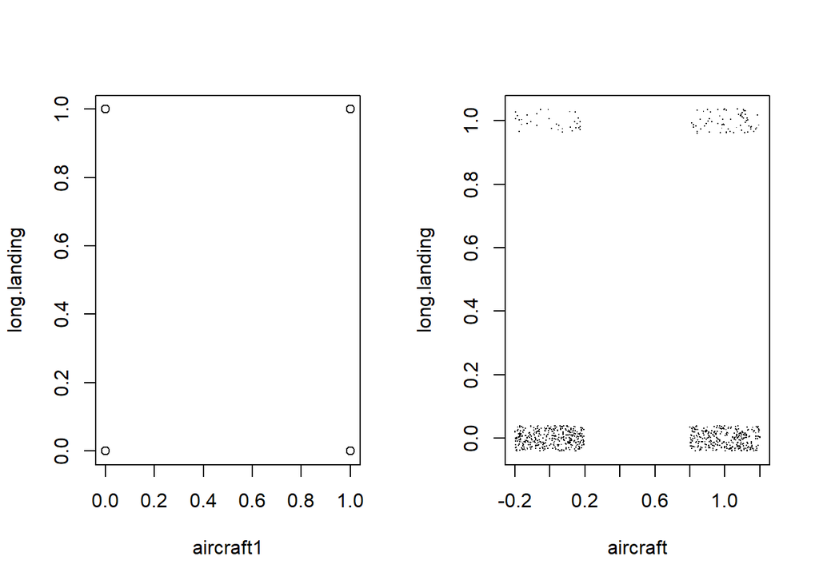

```r
par(mfrow=c(1,2))
plot(long.landing~aircraft1,FAAlog)
plot(jitter(long.landing,0.2)~jitter(aircraft1),FAAlog,xlab ="aircraft",ylab ="long.landing",pch=".")
```

**Fit a model**

**Step 5.** Based on the analysis results in Steps 3-4 and the collinearity result seen in earlier, initiate a “full” model. Fit your model to the data and present your result.

*Understanding:* We observe that speed air and speed ground both are associated with Landing distance, these predictors are have have high magnitude of multi collinearity amongst them. We understand that picking one out of them can help us remove multicollinearity from our model.

Here we choose speed ground rather that speed air because speed air have almost 75% missing values.

```r
#full model
lmod.full_faa<-glm(long.landing~aircraft1+duration+no_pasg+speed_ground+height+pitch,family=binomial,FAAlog)
summary(lmod.full_faa)
```

```
##
## Call:
## glm(formula = long.landing ~ aircraft1 + duration + no_pasg +
##     speed_ground + height + pitch, family = binomial, data = FAAlog)
##
## Deviance Residuals:
##      Min        1Q    Median        3Q       Max
## -2.12757  -0.00078   0.00000   0.00000   2.19551
##
## Coefficients:
##                Estimate Std. Error z value Pr(>|z|)
## (Intercept)  -1.149e+02  2.411e+01  -4.765 1.89e-06 ***
## aircraft1     4.985e+00  1.181e+00   4.221 2.44e-05 ***
## duration      5.361e-03  7.704e-03   0.696   0.4865
## no_pasg       7.420e-03  5.559e-02   0.133   0.8938
## speed_ground  9.795e-01  2.006e-01   4.883 1.05e-06 ***
## height        2.346e-01  7.188e-02   3.264   0.0011 **
## pitch         1.283e+00  8.423e-01   1.523   0.1278
## ---
## Signif. codes:  0 '***' 0.001 '**' 0.01 '*' 0.05 '.' 0.1 ' ' 1
##
## (Dispersion parameter for binomial family taken to be 1)
##
##     Null deviance: 598.240  on 782  degrees of freedom
## Residual deviance:  51.084  on 776  degrees of freedom
## AIC: 65.084
##
## Number of Fisher Scoring iterations: 12
```

Upon regressing full model we realize that **aircraft, speed_ground & height** are significant as per p values.

Doing a further drop1 analysis can help us be confident about this model:

fit a full model after removing collinerity

**drop1 analysis**

```r
#######################################################################
#fit a full model after removing collinerity

drop1(lmod.full_faa,test ="Chi")
```

```
## Single term deletions
##
## Model:
## long.landing ~ aircraft1 + duration + no_pasg + speed_ground +
##     height + pitch
##              Df Deviance    AIC    LRT  Pr(>Chi)
## <none>             51.08  65.08
## aircraft1     1    85.82  97.82  34.73 3.785e-09 ***
## duration      1    51.57  63.57   0.49    0.4836
## no_pasg       1    51.10  63.10   0.02    0.8937
## speed_ground  1   583.37 595.37 532.29 < 2.2e-16 ***
## height        1    72.65  84.65  21.57 3.414e-06 ***
## pitch         1    53.67  65.67   2.59    0.1076
## ---
## Signif. codes:  0 '***' 0.001 '**' 0.01 '*' 0.05 '.' 0.1 ' ' 1
```

```r
drop1(update(lmod.full_faa, ~ . -no_pasg   ), test = "Chi")
```

```
## Single term deletions
##
## Model:
## long.landing ~ aircraft1 + duration + speed_ground + height +
##     pitch
##              Df Deviance    AIC    LRT  Pr(>Chi)
## <none>             51.10  63.10
## aircraft1     1    85.86  95.86  34.76 3.724e-09 ***
## duration      1    51.58  61.58   0.48    0.4894
## speed_ground  1   583.54 593.54 532.44 < 2.2e-16 ***
## height        1    73.47  83.47  22.36 2.257e-06 ***
## pitch         1    53.68  63.68   2.58    0.1084
## ---
## Signif. codes:  0 '***' 0.001 '**' 0.01 '*' 0.05 '.' 0.1 ' ' 1
```

```r
drop1(update(lmod.full_faa, ~ . -duration-no_pasg ), test = "Chi")
```

```
## Single term deletions
##
## Model:
## long.landing ~ aircraft1 + speed_ground + height + pitch
##              Df Deviance    AIC    LRT  Pr(>Chi)
## <none>             51.58  61.58
## aircraft1     1    86.06  94.06  34.48 4.315e-09 ***
## speed_ground  1   583.66 591.66 532.08 < 2.2e-16 ***
## height        1    75.18  83.18  23.60 1.188e-06 ***
## pitch         1    54.40  62.40   2.82   0.09301 .
## ---
## Signif. codes:  0 '***' 0.001 '**' 0.01 '*' 0.05 '.' 0.1 ' ' 1
```

```r
drop1(update(lmod.full_faa, ~ . -duration-no_pasg-pitch ), test = "Chi")
```

```
## Single term deletions
##
## Model:
## long.landing ~ aircraft1 + speed_ground + height
##              Df Deviance    AIC    LRT  Pr(>Chi)
## <none>             54.40  62.40
## aircraft1     1    95.06 101.06  40.66 1.814e-10 ***
## speed_ground  1   583.73 589.73 529.33 < 2.2e-16 ***
## height        1    78.16  84.16  23.76 1.090e-06 ***
## ---
## Signif. codes:  0 '***' 0.001 '**' 0.01 '*' 0.05 '.' 0.1 ' ' 1
```

**Inference:** Using drop1 function we get the same model as in above step

**Automatic Variable selection Based on AIC**

**Step 6.** Use the R function “Step” to perform forward variable selection using AIC. Compare the result with the table obtained in Step 3. Are the results consistent?

```r
#Stepwise


#create null & full model
lmod.null_faa=lm(long.landing~1, data=FAAlog)
#full model
lmod.full_faa<-glm(long.landing~aircraft1+duration+no_pasg+speed_ground+height+pitch,family=binomial,FAAlog)


model_step_F_AIC_LD <- step(lmod.null_faa, scope=list(lower=lmod.null_faa,
                                           upper=lmod.full_faa),
                     direction='forward')
```

```
## Start:  AIC=-1716.37
## long.landing ~ 1
##
##                Df Sum of Sq    RSS     AIC
## + speed_ground  1    34.043 53.185 -2101.8
## + aircraft1     1     1.532 85.696 -1728.2
## + pitch         1     0.284 86.944 -1716.9
## <none>                      87.229 -1716.4
## + height        1     0.048 87.181 -1714.8
## + duration      1     0.027 87.201 -1714.6
## + no_pasg       1     0.024 87.205 -1714.6
##
## Step:  AIC=-2101.76
## long.landing ~ speed_ground
##
##             Df Sum of Sq    RSS     AIC
## + aircraft1  1   2.42022 50.765 -2136.2
## + pitch      1   0.74167 52.444 -2110.8
## + height     1   0.24065 52.945 -2103.3
## <none>                   53.185 -2101.8
## + no_pasg    1   0.03285 53.153 -2100.2
## + duration   1   0.01861 53.167 -2100.0
##
## Step:  AIC=-2136.23
## long.landing ~ speed_ground + aircraft1
##
##            Df Sum of Sq    RSS     AIC
## + height    1   0.27115 50.494 -2138.4
## <none>                  50.765 -2136.2
## + pitch     1   0.10301 50.662 -2135.8
## + duration  1   0.04338 50.722 -2134.9
## + no_pasg   1   0.01837 50.747 -2134.5
##
## Step:  AIC=-2138.42
## long.landing ~ speed_ground + aircraft1 + height
##
##            Df Sum of Sq    RSS     AIC
## <none>                  50.494 -2138.4
## + pitch     1  0.090011 50.404 -2137.8
## + duration  1  0.041892 50.452 -2137.1
## + no_pasg   1  0.024206 50.470 -2136.8
```

Observation: Model suggested by step function is same as above long.landing ~ speed_ground + aircraft1 + height

**Based on BIC**

**Step 7.** Use the R function “Step” to perform forward variable selection using BIC. Compare the result with that from the previous step.

```r
#This model auto uses only 195 rows that have no missing values
model_step_F_BIC_LD <- step(lmod.null_faa, scope=list(lower=lmod.null_faa,
                                           upper=lmod.full_faa),
                     direction='forward',
                     criterion = "BIC",
                     k=log(nrow(FAAlog))
                     )
```

```
## Start:  AIC=-1711.71
## long.landing ~ 1
##
##                Df Sum of Sq    RSS     AIC
## + speed_ground  1    34.043 53.185 -2092.4
## + aircraft1     1     1.532 85.696 -1718.9
## <none>                      87.229 -1711.7
## + pitch         1     0.284 86.944 -1707.6
## + height        1     0.048 87.181 -1705.5
## + duration      1     0.027 87.201 -1705.3
## + no_pasg       1     0.024 87.205 -1705.3
##
## Step:  AIC=-2092.43
## long.landing ~ speed_ground
##
##             Df Sum of Sq    RSS     AIC
## + aircraft1  1   2.42022 50.765 -2122.2
## + pitch      1   0.74167 52.444 -2096.8
## <none>                   53.185 -2092.4
## + height     1   0.24065 52.945 -2089.3
## + no_pasg    1   0.03285 53.153 -2086.2
## + duration   1   0.01861 53.167 -2086.0
##
## Step:  AIC=-2122.24
## long.landing ~ speed_ground + aircraft1
##
##            Df Sum of Sq    RSS     AIC
## <none>                  50.765 -2122.2
## + height    1   0.27115 50.494 -2119.8
## + pitch     1   0.10301 50.662 -2117.2
## + duration  1   0.04338 50.722 -2116.2
## + no_pasg   1   0.01837 50.747 -2115.9
```

**Observation:**

Model suggested by step function BIC is *not* same as above It only selects 2 variables

long.landing ~ speed_ground + aircraft1

HEIGHT : BIC being parsimonious in its approach does not select height as a significant predictor, We can use aliklihood ratio test to find out if adding this variable can improve the overall model

**Liklihood ratio test**

```r
#Selected model
lmod.s_ahsg<-glm(long.landing~aircraft1+height+speed_ground,family=binomial,FAAlog)
summary(lmod.s_ahsg)
```

```
##
## Call:
## glm(formula = long.landing ~ aircraft1 + height + speed_ground,
##     family = binomial, data = FAAlog)
##
## Deviance Residuals:
##      Min        1Q    Median        3Q       Max
## -2.35721  -0.00160  -0.00001   0.00000   2.55053
##
## Coefficients:
##               Estimate Std. Error z value Pr(>|z|)
## (Intercept)  -98.86483   18.64743  -5.302 1.15e-07 ***
## aircraft1      4.91354    1.10438   4.449 8.62e-06 ***
## height         0.22063    0.06028   3.660 0.000252 ***
## speed_ground   0.88939    0.16684   5.331 9.79e-08 ***
## ---
## Signif. codes:  0 '***' 0.001 '**' 0.01 '*' 0.05 '.' 0.1 ' ' 1
##
## (Dispersion parameter for binomial family taken to be 1)
##
##     Null deviance: 598.240  on 782  degrees of freedom
## Residual deviance:  54.401  on 779  degrees of freedom
## AIC: 62.401
##
## Number of Fisher Scoring iterations: 11
```

```r
#BIC Model
lmod.asg<-glm(long.landing~aircraft1+speed_ground,family=binomial,FAAlog)
summary(lmod.asg)
```

```
##
## Call:
## glm(formula = long.landing ~ aircraft1 + speed_ground, family = binomial,
##     data = FAAlog)
##
## Deviance Residuals:
##      Min        1Q    Median        3Q       Max
## -2.27583  -0.01388  -0.00038   0.00000   2.58037
##
## Coefficients:
##               Estimate Std. Error z value Pr(>|z|)
## (Intercept)  -61.01550    8.91176  -6.847 7.56e-12 ***
## aircraft1      3.27823    0.74478   4.402 1.07e-05 ***
## speed_ground   0.58743    0.08668   6.777 1.23e-11 ***
## ---
## Signif. codes:  0 '***' 0.001 '**' 0.01 '*' 0.05 '.' 0.1 ' ' 1
##
## (Dispersion parameter for binomial family taken to be 1)
##
##     Null deviance: 598.240  on 782  degrees of freedom
## Residual deviance:  78.164  on 780  degrees of freedom
## AIC: 84.164
##
## Number of Fisher Scoring iterations: 10
```

```r
anova(lmod.asg,lmod.s_ahsg,test="Chi")
```

```
## Analysis of Deviance Table
##
## Model 1: long.landing ~ aircraft1 + speed_ground
## Model 2: long.landing ~ aircraft1 + height + speed_ground
##   Resid. Df Resid. Dev Df Deviance Pr(>Chi)
## 1       780     78.164
## 2       779     54.401  1   23.762 1.09e-06 ***
## ---
## Signif. codes:  0 '***' 0.001 '**' 0.01 '*' 0.05 '.' 0.1 ' ' 1
```

**Inference:**

Test suggests that bigger model model is significantly different from smaller model hence we select the bigger model.

**Final Analysis: Report**

**Step 8.** Now,You are scheduled to meet with an FAA agent who wants to know “what are risk factors for long landings and how do they influence its occurrence?”.

```r
#AIC BIC Comparision
print(paste("AIC of BIC suggested (aircraft+speed_air) model is",round(AIC(lmod.asg),4)),quote=FALSE)
```

[output not shown]

```r
print(paste("BIC of BIC suggested (aircraft+speed_air)  model is",round(BIC(lmod.asg),4)),quote=FALSE)
```

[output not shown]

```r
print(paste("AIC of selected model(aircraft+speed_ground+height) is",round(AIC(lmod.s_ahsg),4)),quote=FALSE)
```

```
## [1] AIC of selected model(aircraft+speed_ground+height) is 62.4014
```

```r
print(paste("BIC of selected model(aircraft+speed_ground+height) is",round(BIC(lmod.s_ahsg),4)),quote=FALSE)
```

```
## [1] BIC of selected model(aircraft+speed_ground+height) is 81.0539
```

```r
f<-cbind(coef(summary(lmod.s_ahsg)),exp(coef(summary(lmod.s_ahsg))[,1]))
colnames(f)<-c("Estimate","Std. Error","z value","Pr(>|z|)","Odds Ratio" )
f
```

```
##                 Estimate Std. Error   z value     Pr(>|z|)   Odds Ratio
## (Intercept)  -98.8648279 18.6474315 -5.301793 1.146706e-07 1.157579e-43
## aircraft1      4.9135434  1.1043832  4.449129 8.621918e-06 1.361209e+02
## height         0.2206339  0.0602816  3.660054 2.521616e-04 1.246867e+00
## speed_ground   0.8893937  0.1668449  5.330661 9.785594e-08 2.433654e+00
```

*We observe that*

Hence these predictors are very important to correctly predic the landing distance over run.

### 4.2 Risky Landing

**Identifying important factors using the binary data of “risky.landing”**

**Step 9.** Repeat Steps 1-7 but using “risky.landing” as the binary response

**Univariate Analysis**

**Step2.b**

Identifying important factors using the binary data of “risky.landing”.

Use a pie chart or a histogram to show the distribution of “risky.landing”.

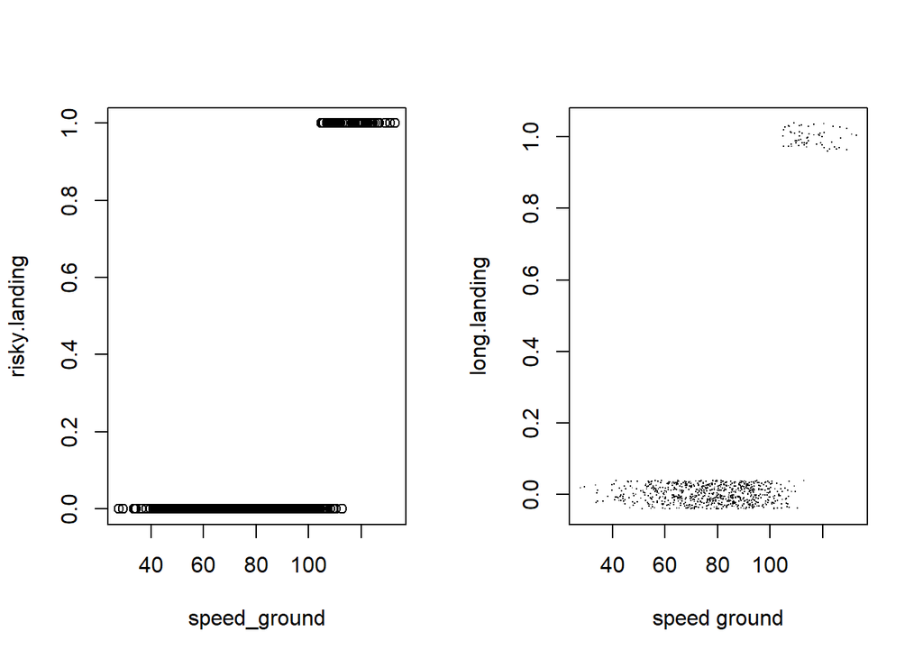

```r
FAAlog$aircraft1<-ifelse(FAAlog$aircraft=='boeing',as.numeric(1),as.numeric(0))

par(mfrow=c(1,2))
plot(risky.landing~speed_ground,FAAlog)
plot(jitter(risky.landing,0.2)~jitter(speed_ground),FAAlog,xlab ="speed ground",ylab ="long.landing",pch=".")
```

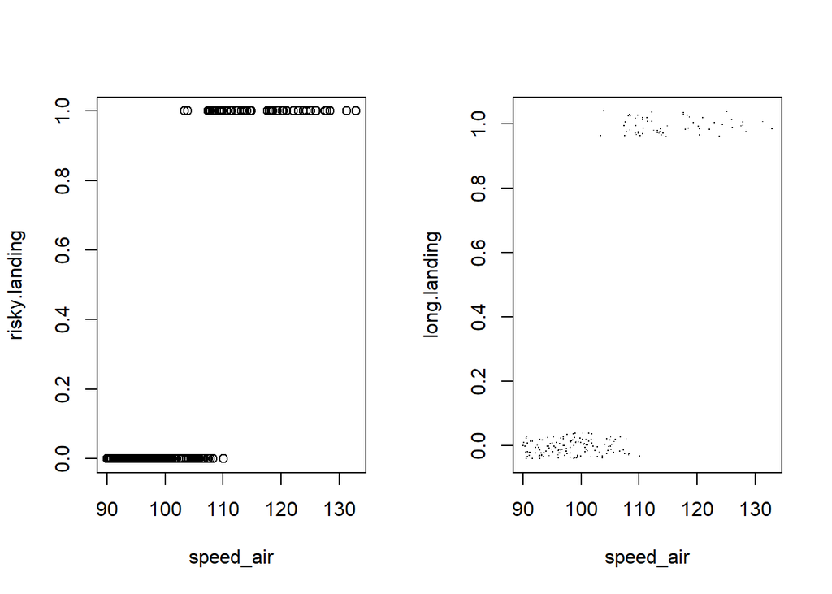

```r
par(mfrow=c(1,2))
plot(risky.landing~speed_air,FAAlog)
plot(jitter(risky.landing,0.2)~jitter(speed_air),FAAlog,xlab ="speed_air",ylab ="long.landing",pch=".")
```

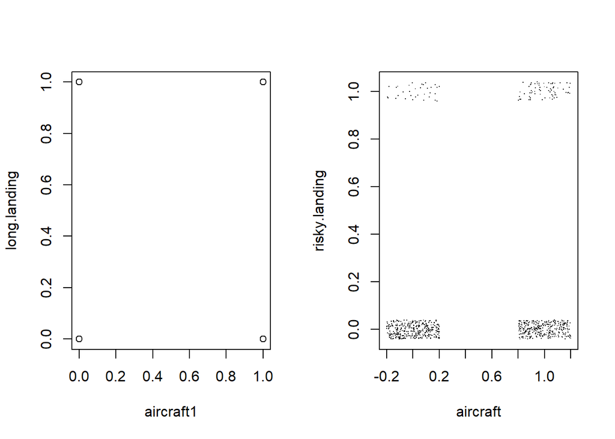

```r
par(mfrow=c(1,2))
plot(long.landing~aircraft1,FAAlog)
plot(jitter(long.landing,0.2)~jitter(aircraft1),FAAlog,xlab ="aircraft",ylab ="risky.landing",pch=".")
```

```r
#names(FAA_U_RmvNA)
#FAAlog_R<-FAA_U_RmvNA[,c(1,2,3,4,5,6,7,10)]

# A model with all variables available
R_lmod.aircraft<-glm(risky.landing~aircraft,family=binomial,FAAlog)
R_lmod.duration<-glm(risky.landing~duration,family=binomial,FAAlog)
R_lmod.no_pasg<-glm(risky.landing~no_pasg,family=binomial,FAAlog)
R_lmod.speed_ground<-glm(risky.landing~speed_ground,family=binomial,FAAlog)
R_lmod.speed_air<-glm(risky.landing~speed_air,family=binomial,FAAlog)
R_lmod.height<-glm(risky.landing~height,family=binomial,FAAlog)
R_lmod.pitch<-glm(risky.landing~pitch,family=binomial,FAAlog)

Rv1<-c('aircraft',round(coef(R_lmod.aircraft)[1],2),coef(R_lmod.aircraft)[2],exp(coef(R_lmod.aircraft))[1],exp(coef(R_lmod.aircraft))[2],
     sign<-ifelse(coef(R_lmod.aircraft)[2]==-1,"Negative","Positive"),coef(summary(R_lmod.aircraft))[,4])
Rv2<-c('duration',coef(R_lmod.duration)[1],coef(R_lmod.duration)[2],exp(coef(R_lmod.duration))[1],exp(coef(R_lmod.duration))[2],
     sign<-ifelse(coef(R_lmod.duration)[2]==-1,"Negative","Positive"),coef(summary(R_lmod.duration))[,4])
Rv3<-c('no_pasg',coef(R_lmod.no_pasg)[1],coef(R_lmod.no_pasg)[2],exp(coef(R_lmod.no_pasg))[1],exp(coef(R_lmod.no_pasg))[2],
      sign<-ifelse(sign(coef(R_lmod.no_pasg)[2])==-1,"Negative","Positive"),coef(summary(R_lmod.no_pasg))[,4])
Rv4<-c('speed_ground',coef(R_lmod.speed_ground)[1],coef(R_lmod.speed_ground)[2],exp(coef(R_lmod.speed_ground))[1],exp(coef(R_lmod.speed_ground))[2],
      sign<-ifelse(coef(R_lmod.speed_ground)[2]==-1,"Negative","Positive"),coef(summary(R_lmod.speed_ground))[,4])
Rv5<-c('speed_air',coef(R_lmod.speed_air)[1],coef(R_lmod.speed_air)[2],exp(coef(R_lmod.speed_air))[1],exp(coef(R_lmod.speed_air))[2],
      sign<-ifelse(coef(R_lmod.speed_air)[2]==-1,"Negative","Positive"),coef(summary(R_lmod.speed_air))[,4])
Rv6<-c('height',coef(R_lmod.height)[1],coef(R_lmod.height)[2],exp(coef(R_lmod.height))[1],exp(coef(R_lmod.height))[2],
      sign<-ifelse(coef(R_lmod.height)[2]==-1,"Negative","Positive"),coef(summary(R_lmod.height))[,4])
Rv7<-c('pitch',coef(R_lmod.pitch)[1],coef(R_lmod.pitch)[2],exp(coef(R_lmod.pitch))[1],exp(coef(R_lmod.pitch))[2],
      sign<-ifelse(coef(R_lmod.pitch)[2]==-1,"Negative","Positive"),coef(summary(R_lmod.pitch))[,4])

Rd<-data.frame(rbind(Rv1,Rv2,Rv3,Rv4,Rv5,Rv6,Rv7))
colnames(Rd)<-c('Name','B0','B1','OddsRto_B0','OddsRto_B1','Sign','Pvalue_B0','Pvalue_B1')
Rd$B0<-round(as.numeric(as.character(Rd$B0)),2)
Rd$B1<-round(as.numeric(as.character(Rd$B1)),2)
Rd$OddsRto_B0<-round(as.numeric(as.character(Rd$OddsRto_B0)),2)
Rd$OddsRto_B1<-round(as.numeric(as.character(Rd$OddsRto_B1)),2)
Rd$Pvalue_B0<-as.numeric(as.character(Rd$Pvalue_B0))
Rd$Pvalue_B1<-as.numeric(as.character(Rd$Pvalue_B1))
Rd<-arrange(Rd,Pvalue_B1,Pvalue_B0)
Rd$signif<-ifelse(Rd$Pvalue_B1<0.05,'S','I')
Rd[,c(1,2,3,6,7,8,9)]
```

```
##           Name     B0    B1     Sign    Pvalue_B0    Pvalue_B1 signif
## 1 speed_ground -64.40  0.60 Positive 9.638076e-08 1.085926e-07      S
## 2    speed_air -91.48  0.85 Positive 5.733858e-06 5.720457e-06      S
## 3     aircraft  -3.04  0.93 Positive 2.175652e-36 1.455107e-03      S
## 4      no_pasg  -1.00 -0.03 Negative 3.476978e-01 1.594340e-01      I
## 5        pitch  -3.83  0.33 Positive 3.336993e-04 2.018700e-01      I
## 6     duration  -2.31  0.00 Positive 2.428451e-07 6.730755e-01      I
## 7       height  -2.37  0.00 Positive 6.269855e-08 7.777416e-01      I
```

**Observation:**

** Fit a model**

Here we fit a full model, based on prior collinearity analysis we remove speed air fit a full model after removing collinerity

```r
#full model
Rlmod.full_faa<-glm(risky.landing~aircraft1+duration+no_pasg+speed_ground+height+pitch,family=binomial,FAAlog)
summary(Rlmod.full_faa)#aircraft and speed_air
```

```
##
## Call:
## glm(formula = risky.landing ~ aircraft1 + duration + no_pasg +
##     speed_ground + height + pitch, family = binomial, data = FAAlog)
##
## Deviance Residuals:
##      Min        1Q    Median        3Q       Max
## -2.44763  -0.00011   0.00000   0.00000   1.85688
##
## Coefficients:
##                Estimate Std. Error z value Pr(>|z|)
## (Intercept)  -1.022e+02  2.811e+01  -3.635 0.000278 ***
## aircraft1     4.406e+00  1.562e+00   2.821 0.004783 **
## duration      7.386e-04  1.214e-02   0.061 0.951498
## no_pasg      -8.590e-02  6.011e-02  -1.429 0.152955
## speed_ground  9.366e-01  2.476e-01   3.782 0.000155 ***
## height        4.214e-02  4.618e-02   0.913 0.361502
## pitch         6.083e-01  8.000e-01   0.760 0.447088
## ---
## Signif. codes:  0 '***' 0.001 '**' 0.01 '*' 0.05 '.' 0.1 ' ' 1
##
## (Dispersion parameter for binomial family taken to be 1)
##
##     Null deviance: 423.535  on 782  degrees of freedom
## Residual deviance:  36.372  on 776  degrees of freedom
## AIC: 50.372
##
## Number of Fisher Scoring iterations: 12
```

**drop1 analysis:**

```r
drop1(Rlmod.full_faa,test ="Chi")
```

```
## Single term deletions
##
## Model:
## risky.landing ~ aircraft1 + duration + no_pasg + speed_ground +
##     height + pitch
##              Df Deviance    AIC    LRT  Pr(>Chi)
## <none>             36.37  50.37
## aircraft1     1    49.90  61.90  13.53 0.0002345 ***
## duration      1    36.38  48.38   0.00 0.9515067
## no_pasg       1    38.62  50.62   2.25 0.1334514
## speed_ground  1   410.63 422.63 374.26 < 2.2e-16 ***
## height        1    37.23  49.23   0.86 0.3549199
## pitch         1    36.96  48.96   0.59 0.4423665
## ---
## Signif. codes:  0 '***' 0.001 '**' 0.01 '*' 0.05 '.' 0.1 ' ' 1
```

```r
drop1(update(Rlmod.full_faa, ~ . -duration), test = "Chi")
```

```
## Single term deletions
##
## Model:
## risky.landing ~ aircraft1 + no_pasg + speed_ground + height +
##     pitch
##              Df Deviance    AIC    LRT  Pr(>Chi)
## <none>             36.38  48.38
## aircraft1     1    49.91  59.91  13.53 0.0002347 ***
## no_pasg       1    38.82  48.82   2.44 0.1182167
## speed_ground  1   410.75 420.75 374.37 < 2.2e-16 ***
## height        1    37.30  47.30   0.93 0.3351600
## pitch         1    36.98  46.98   0.61 0.4352093
## ---
## Signif. codes:  0 '***' 0.001 '**' 0.01 '*' 0.05 '.' 0.1 ' ' 1
```

```r
drop1(update(Rlmod.full_faa, ~ . -duration-pitch ), test = "Chi")
```

```
## Single term deletions
##
## Model:
## risky.landing ~ aircraft1 + no_pasg + speed_ground + height
##              Df Deviance    AIC    LRT  Pr(>Chi)
## <none>             36.98  46.98
## aircraft1     1    57.06  65.06  20.08 7.439e-06 ***
## no_pasg       1    39.30  47.30   2.31    0.1285
## speed_ground  1   410.77 418.77 373.78 < 2.2e-16 ***
## height        1    37.56  45.56   0.57    0.4485
## ---
## Signif. codes:  0 '***' 0.001 '**' 0.01 '*' 0.05 '.' 0.1 ' ' 1
```

```r
drop1(update(Rlmod.full_faa, ~ . -duration-pitch-height ), test = "Chi")
```

```
## Single term deletions
##
## Model:
## risky.landing ~ aircraft1 + no_pasg + speed_ground
##              Df Deviance    AIC    LRT  Pr(>Chi)
## <none>             37.56  45.56
## aircraft1     1    57.18  63.18  19.62  9.45e-06 ***
## no_pasg       1    39.96  45.96   2.40    0.1216
## speed_ground  1   410.79 416.79 373.24 < 2.2e-16 ***
## ---
## Signif. codes:  0 '***' 0.001 '**' 0.01 '*' 0.05 '.' 0.1 ' ' 1
```

```r
drop1(update(Rlmod.full_faa, ~ . -duration-height-pitch-no_pasg), test = "Chi")
```

```
## Single term deletions
##
## Model:
## risky.landing ~ aircraft1 + speed_ground
##              Df Deviance    AIC    LRT  Pr(>Chi)
## <none>             39.96  45.96
## aircraft1     1    57.99  61.99  18.03 2.171e-05 ***
## speed_ground  1   412.53 416.53 372.57 < 2.2e-16 ***
## ---
## Signif. codes:  0 '***' 0.001 '**' 0.01 '*' 0.05 '.' 0.1 ' ' 1
```

```r
#suggested model : aircraft and speed ground only
Rlmod.s<-glm(risky.landing~aircraft1+speed_ground,family=binomial,FAAlog)
summary(Rlmod.s)
```

```
##
## Call:
## glm(formula = risky.landing ~ aircraft1 + speed_ground, family = binomial,
##     data = FAAlog)
##
## Deviance Residuals:
##      Min        1Q    Median        3Q       Max
## -2.22465  -0.00014   0.00000   0.00000   1.60326
##
## Coefficients:
##               Estimate Std. Error z value Pr(>|z|)
## (Intercept)  -100.6448    24.8834  -4.045 5.24e-05 ***
## aircraft1       3.9763     1.2520   3.176  0.00149 **
## speed_ground    0.9132     0.2258   4.044 5.25e-05 ***
## ---
## Signif. codes:  0 '***' 0.001 '**' 0.01 '*' 0.05 '.' 0.1 ' ' 1
##
## (Dispersion parameter for binomial family taken to be 1)
##
##     Null deviance: 423.535  on 782  degrees of freedom
## Residual deviance:  39.955  on 780  degrees of freedom
## AIC: 45.955
##
## Number of Fisher Scoring iterations: 12
```

**Automatic Variable Selection**

**AIC** **Step 6(2).** Use the R function “Step” to perform forward variable selection using AIC. Compare the result with the table obtained in Step 3.

Are the results consistent?

```r
#Stepwise

#create null & full model
Rlmod.null_faa=lm(risky.landing~1, data=FAAlog)
#full model
Rlmod.full_faa<-glm(risky.landing~aircraft1+duration+no_pasg+speed_ground+height+pitch,family=binomial,FAAlog)


#This model auto uses only 195 rows that have no missing values
Rmodel_step_F_AIC <- step(Rlmod.null_faa, scope=list(lower=Rlmod.null_faa,
                                           upper=Rlmod.full_faa),
                     direction='forward')
```

```
## Start:  AIC=-2071.78
## risky.landing ~ 1
##
##                Df Sum of Sq    RSS     AIC
## + speed_ground  1   16.5163 38.886 -2347.0
## + aircraft1     1    0.7593 54.643 -2080.6
## <none>                      55.402 -2071.8
## + no_pasg       1    0.1403 55.262 -2071.8
## + pitch         1    0.1155 55.287 -2071.4
## + duration      1    0.0126 55.390 -2070.0
## + height        1    0.0056 55.397 -2069.9
##
## Step:  AIC=-2346.96
## risky.landing ~ speed_ground
##
##             Df Sum of Sq    RSS     AIC
## + aircraft1  1   1.19415 37.692 -2369.4
## + pitch      1   0.32298 38.563 -2351.5
## + no_pasg    1   0.15469 38.731 -2348.1
## <none>                   38.886 -2347.0
## + height     1   0.01303 38.873 -2345.2
## + duration   1   0.00953 38.876 -2345.2
##
## Step:  AIC=-2369.38
## risky.landing ~ speed_ground + aircraft1
##
##            Df Sum of Sq    RSS     AIC
## + no_pasg   1  0.130547 37.561 -2370.1
## <none>                  37.692 -2369.4
## + pitch     1  0.034664 37.657 -2368.1
## + duration  1  0.021931 37.670 -2367.8
## + height    1  0.018309 37.673 -2367.8
##
## Step:  AIC=-2370.1
## risky.landing ~ speed_ground + aircraft1 + no_pasg
##
##            Df Sum of Sq    RSS     AIC
## <none>                  37.561 -2370.1
## + pitch     1  0.033941 37.527 -2368.8
## + height    1  0.022276 37.539 -2368.6
## + duration  1  0.018207 37.543 -2368.5
```

```r
#aic model
Rlmod.AIC<-glm(risky.landing ~ speed_ground + aircraft1 + no_pasg,family=binomial,FAAlog)
```

AIC STEP function suggests that significant predictors are:

risky.landing ~ speed_ground + aircraft1 + no_pasg

**BIC**

**Step 7(2).** Use the R function “Step” to perform forward variable selection using BIC. Compare the result with that from the previous step.

```r
#This model auto uses only 195 rows that have no missing values
Rmodel_step_F_BIC <- step(Rlmod.null_faa, scope=list(lower=Rlmod.null_faa,
                                           upper=Rlmod.full_faa),
                     direction='forward',
                     criterion = "BIC",
                     k=log(nrow(FAAlog))
                     )
```

```
## Start:  AIC=-2067.12
## risky.landing ~ 1
##
##                Df Sum of Sq    RSS     AIC
## + speed_ground  1   16.5163 38.886 -2337.6
## + aircraft1     1    0.7593 54.643 -2071.3
## <none>                      55.402 -2067.1
## + no_pasg       1    0.1403 55.262 -2062.4
## + pitch         1    0.1155 55.287 -2062.1
## + duration      1    0.0126 55.390 -2060.6
## + height        1    0.0056 55.397 -2060.5
##
## Step:  AIC=-2337.63
## risky.landing ~ speed_ground
##
##             Df Sum of Sq    RSS     AIC
## + aircraft1  1   1.19415 37.692 -2355.4
## <none>                   38.886 -2337.6
## + pitch      1   0.32298 38.563 -2337.5
## + no_pasg    1   0.15469 38.731 -2334.1
## + height     1   0.01303 38.873 -2331.2
## + duration   1   0.00953 38.876 -2331.2
##
## Step:  AIC=-2355.39
## risky.landing ~ speed_ground + aircraft1
##
##            Df Sum of Sq    RSS     AIC
## <none>                  37.692 -2355.4
## + no_pasg   1  0.130547 37.561 -2351.4
## + pitch     1  0.034664 37.657 -2349.4
## + duration  1  0.021931 37.670 -2349.2
## + height    1  0.018309 37.673 -2349.1
```

Model suggested by BIC is: risky.landing ~ speed_ground + aircraft1

**Liklihood Ratio test**

```r
#model
anova(Rlmod.s,Rlmod.AIC,test="Chi")#cannot reject null hypothesis
```

```
## Analysis of Deviance Table
##
## Model 1: risky.landing ~ aircraft1 + speed_ground
## Model 2: risky.landing ~ speed_ground + aircraft1 + no_pasg
##   Resid. Df Resid. Dev Df Deviance Pr(>Chi)
## 1       780     39.955
## 2       779     37.559  1   2.3964   0.1216
```

**Interpretation**

Liklihood ratio test suggests we can select the smaller model Hence, we select the model with Speed_ground and aircraft

```r
#AIC MODEL
print(paste("AIC of AIC model is",round(AIC(Rlmod.AIC),4)),quote=FALSE)
```

```
## [1] AIC of AIC model is 45.5589
```

```r
print(paste("AIC of AIC model is",round(BIC(Rlmod.AIC),4)),quote=FALSE)
```

[output not shown]

```r
#SELECTED FINAL BIC & DROP FUNCTION
print(paste("AIC of FINAL model(DROP FUNCTION) is",round(AIC(Rlmod.s),4)),quote=FALSE)
```

```
## [1] AIC of FINAL model(DROP FUNCTION) is 45.9553
```

```r
print(paste("AIC of FINAL model(DROP FUNCTION) is",round(BIC(Rlmod.s),4)),quote=FALSE)
```

[output not shown]

```r
coef(summary(Rlmod.s))
```

```
##                  Estimate Std. Error   z value     Pr(>|z|)
## (Intercept)  -100.6447977 24.8834111 -4.044654 5.240037e-05
## aircraft1       3.9763497  1.2520073  3.175980 1.493315e-03
## speed_ground    0.9131614  0.2258071  4.043989 5.254930e-05
```

```r
Rf<-cbind(coef(summary(Rlmod.s)),exp(coef(summary(Rlmod.s))[,1]))
colnames(Rf)<-c("Estimate","Std. Error","z value","Pr(>|z|)","Odds Ratio" )
Rf
```

```
##                  Estimate Std. Error   z value     Pr(>|z|)   Odds Ratio
## (Intercept)  -100.6447977 24.8834111 -4.044654 5.240037e-05 1.952179e-44
## aircraft1       3.9763497  1.2520073  3.175980 1.493315e-03 5.332204e+01
## speed_ground    0.9131614  0.2258071  4.043989 5.254930e-05 2.492189e+00
```

Hence these predictors are very important to correctly predic the landing distance over run.

### 4.4 ROC Curve

**Step 12.** Plot the **ROC curve** (sensitivity versus 1-specificity) for each model (see pp.32-33 in Lecture 4 slides). Draw the two curves in the same plot. Do you have any comment?

**long landing**

```r
linpred.l<-predict(lmod.s_ahsg) # Linear predictor
predprob.l<-predict(lmod.s_ahsg,type ="response") #predicted probabilities

predout.l<-(ifelse(predprob.l<0.5,"no","yes")) ### Predicted outcomes using 0.5 as the threshold
FAAlog.l<-data.frame(FAAlog,predprob.l,predout.l)
xtabs(~long.landing+predout.l,FAAlog.l)
```

```
##             predout.l
## long.landing  no yes
##            0 679   4
##            1   6  94
```

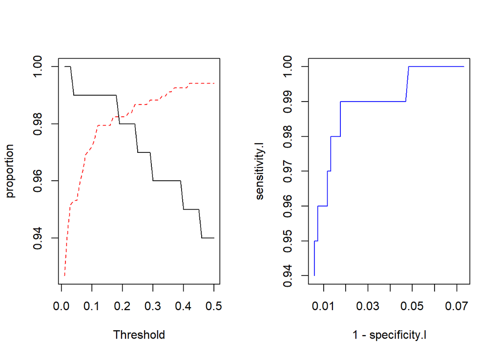

```r
thresh<-seq(0.01,0.5,0.01)
sensitivity.l<-specificity.l<-rep(NA,length(thresh))
for(j in seq (along=thresh)){
  pp.l<-ifelse(FAAlog.l$predprob.l< thresh[j],"no","yes")
  xx.l<-xtabs(~long.landing+pp.l,FAAlog.l)
  specificity.l[j]<-xx.l[1,1]/(xx.l[1,1]+xx.l[1,2])
  sensitivity.l[j]<-xx.l[2,2]/(xx.l[2,1]+xx.l[2,2])

}
par(mfrow=c(1,2))
matplot(thresh,cbind(sensitivity.l,specificity.l),type="l", xlab ="Threshold",ylab="proportion",lty=1:2)
plot(1-specificity.l,sensitivity.l,type="l",col="Blue");abline(0,1,lty=2)
```

**Risky landing**

```r
linpredF<-predict(Rlmod.s) # Linear predictor
predprobF<-predict(Rlmod.s,type ="response") #predicted probabilities

predoutF<-(ifelse(predprobF<0.5,"no","yes")) ### Predicted outcomes using 0.5 as the threshold
FAAlog.F<-data.frame(FAAlog,predprobF,predoutF)
xtabs(~risky.landing+predoutF,FAAlog)
```

```
##              predoutF
## risky.landing  no yes
##             0 717   6
##             1   6  54
```

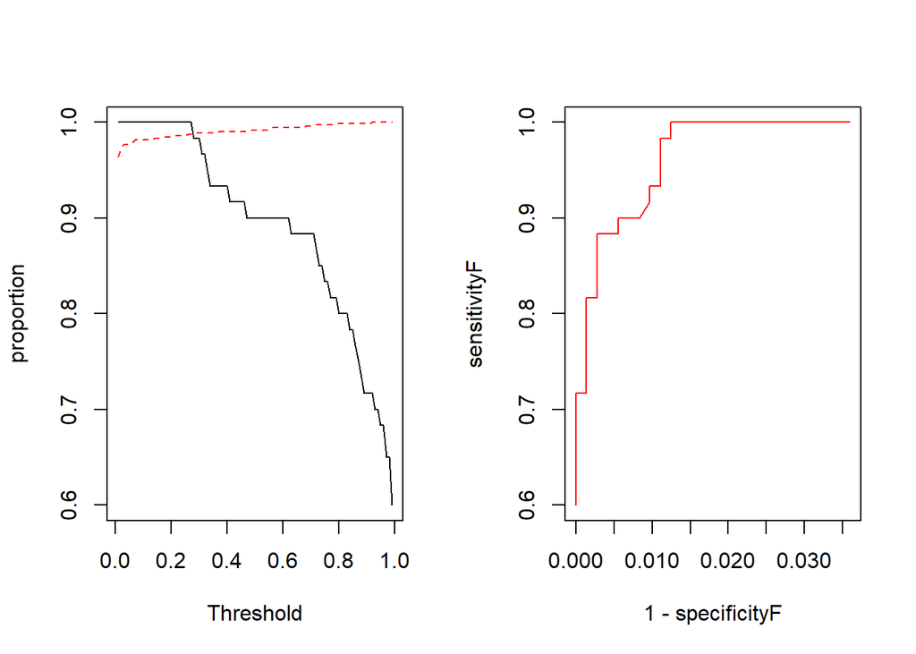

```r
threshF<-seq(0.01,0.999,0.01)
sensitivityF<-specificityF<-rep(NA,length(threshF))
for(j in seq (along=threshF)){
  ppF<-ifelse(FAAlog.F$predprobF< threshF[j],"no","yes")
  xxF<-xtabs(~risky.landing+ppF,FAAlog)
  specificityF[j]<-xxF[1,1]/(xxF[1,1]+xxF[1,2])
  sensitivityF[j]<-xxF[2,2]/(xxF[2,1]+xxF[2,2])

}
par(mfrow=c(1,2))
matplot(threshF,cbind(sensitivityF,specificityF),type="l", xlab ="Threshold",ylab="proportion",lty=1:2)
plot(1-specificityF,sensitivityF,type="l",col="Red");abline(0,1,lty=2)
```

**PLOTING both togather:**

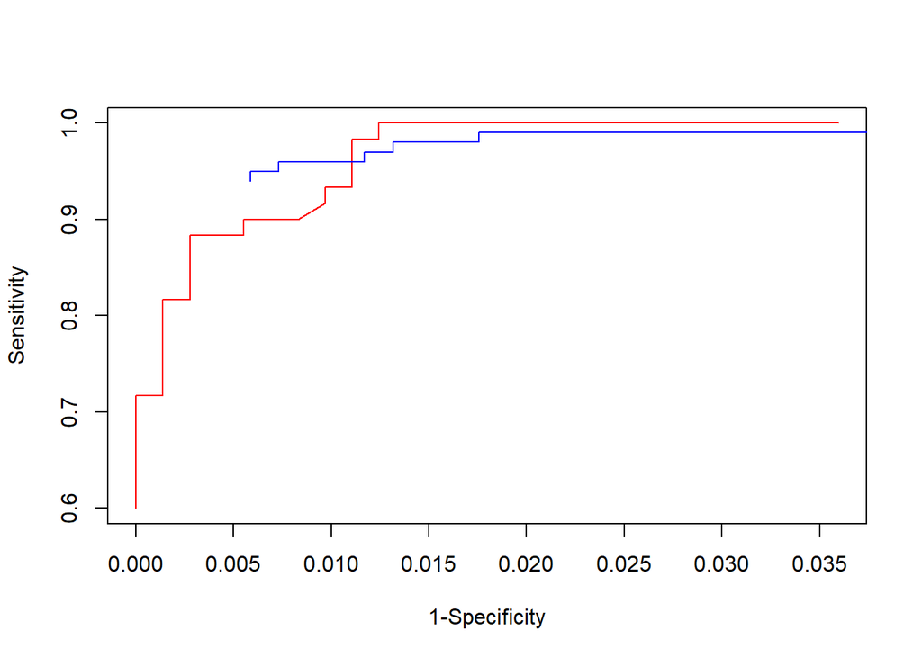

```r
plot(1-specificityF,sensitivityF,type="l",col="Red",xlab="1-Specificity",ylab="Sensitivity")
lines(1-specificity.l,sensitivity.l,col="Blue")
```

### 4.5 Prediction

**Step 13.**

A commercial airplane is passing over the threshold of the runway, at this moment we have its basic information and measures of its airborne performance (Boeing, duration=200, no_pasg=80, speed_ground=115, speed_air=120, height=40, pitch=4). Predict its probability of being a long landing and a risky landing, respectively. Report the predicted probability as well as its 95% confidence interval. **Long landing**

```r
new.ind<-data.frame(aircraft1=1,duration=200,no_pasg=80,speed_ground=115,speed_air=120,height=40,pitch=4)
predict(lmod.s_ahsg,newdata=new.ind,type ="link") ### Linear predictor
```

```
##        1
## 17.15434
```

```r
predict(lmod.s_ahsg,newdata= new.ind,type ="response") ### Probability
```

```
## 1
## 1
```

```r
### Predict the value with its standard error
predict(lmod.s_ahsg,newdata=new.ind,type ="link",se=T) ### Linear predictor
```

```
## $fit
##        1
## 17.15434
##
## $se.fit
## [1] 3.366708
##
## $residual.scale
## [1] 1
```

```r
predict(lmod.s_ahsg,newdata= new.ind,type ="response",se=T) ### Probability
```

```
## $fit
## 1
## 1
##
## $se.fit
##            1
## 1.194452e-07
##
## $residual.scale
## [1] 1
```

```r
round(ilogit(c( 17.15434+1.96*3.366708, 17.15434+1.96*3.366708)),3 ) ### Confidence interval
```

```
## [1] 1 1
```

```r
round(c(1+1.96*1.194452e-07,1-1.96*1.194452e-07), 3 ) ### Confidence interval
```

```
## [1] 1 1
```

We observe that confidence Interval is 1,1 which is an indicator of better prediction ability of our selected model

**Risky landing**

```r
predict(Rlmod.s,newdata=new.ind,type ="link") ### Linear predictor
```

```
##        1
## 8.345109
```

```r
predict(Rlmod.s,newdata= new.ind,type ="response") ### Probability
```

```
##         1
## 0.9997625
```

```r
### Predict the value with its standard error
predict(Rlmod.s,newdata=new.ind,type ="link",se=T) ### Linear predictor
```

```
## $fit
##        1
## 8.345109
##
## $se.fit
## [1] 2.098615
##
## $residual.scale
## [1] 1
```

```r
predict(Rlmod.s,newdata= new.ind,type ="response",se=T) ### Probability
```

```
## $fit
##         1
## 0.9997625
##
## $se.fit
##            1
## 0.0004983008
##
## $residual.scale
## [1] 1
```

```r
round(ilogit(c( 8.345109+1.96*2.098615, 8.345109+1.96*2.098615)),5 ) ### Confidence interval
```

```
## [1] 1 1
```

```r
round(c(0.9997625+1.96*0.0004983008 ,0.9997625-1.96*0.0004983008), 5 ) ### Confidence interval
```

```
## [1] 1.00074 0.99879
```

We observe that confidence Interval marginally different ,because the difference is very small we can avoid it.

## 5.0 Other functions

### 5.1 Probit vz Cloglog

Compare models with different link functions

```r
lmod.s_ahsg_probit<-glm(long.landing~aircraft1+height+speed_ground,family=binomial(link=probit),FAAlog)
lmod.s_ahsg_cloglog<-glm(long.landing~aircraft1+height+speed_ground,family=binomial(link=cloglog),FAAlog)
df.compare.coef<-cbind(round(coef(lmod.s_ahsg),3),round(coef(lmod.s_ahsg_probit),3),round(coef(lmod.s_ahsg_cloglog),3))
colnames(df.compare.coef)<-c('logit','probit','cloglog')
df.compare.coef
```

```
##                logit  probit cloglog
## (Intercept)  -98.865 -53.932 -67.868
## aircraft1      4.914   2.694   3.664
## height         0.221   0.117   0.153
## speed_ground   0.889   0.486   0.602
```

**Inference:** coefficient of variable is highest in logit function followed by comp log log function and then by probit

```r
predval<-sapply(list(lmod.s_ahsg,lmod.s_ahsg_probit,lmod.s_ahsg_cloglog),fitted)
colnames(predval)<- c('logit','probit','cloglog')
```

Compare top ten values

```r
predval[1:10 ,]
```

```
##           logit       probit      cloglog
## 1  9.996897e-01 9.999947e-01 1.000000e+00
## 2  9.305530e-01 9.202875e-01 9.652767e-01
## 3  2.649443e-12 2.220446e-16 8.265371e-09
## 4  1.947901e-05 1.395946e-09 3.829680e-04
## 5  2.220446e-16 2.220446e-16 8.322862e-11
## 6  1.323259e-08 2.220446e-16 2.878625e-06
## 7  2.220446e-16 2.220446e-16 8.654803e-13
## 8  2.220446e-16 2.220446e-16 2.117752e-12
## 9  3.894756e-05 1.207688e-08 6.235964e-04
## 10 2.220446e-16 2.220446e-16 5.111611e-10
```

Compare values between 03 and 0.5

```r
predval[fitted(lmod.s_ahsg)>0.3 & fitted(lmod.s_ahsg) <0.5,]
```

```
##         logit    probit   cloglog
## 24  0.3968172 0.4050834 0.3547947
## 60  0.3434765 0.3422366 0.3271934
## 202 0.4178148 0.4349099 0.3606496
## 399 0.3284088 0.3449841 0.2215693
## 667 0.4584596 0.4561809 0.3081406
## 693 0.3688203 0.3523023 0.2688676
```

Compare Values <0.01

```r
predval[fitted(lmod.s_ahsg)<0.01,]
```

```
##            logit       probit      cloglog
## 3   2.649443e-12 2.220446e-16 8.265371e-09
## 4   1.947901e-05 1.395946e-09 3.829680e-04
## 5   2.220446e-16 2.220446e-16 8.322862e-11
## 6   1.323259e-08 2.220446e-16 2.878625e-06
## 7   2.220446e-16 2.220446e-16 8.654803e-13
## 8   2.220446e-16 2.220446e-16 2.117752e-12
## 9   3.894756e-05 1.207688e-08 6.235964e-04
## 10  2.220446e-16 2.220446e-16 5.111611e-10
## 11  2.220446e-16 2.220446e-16 1.792280e-11
## 14  2.220446e-16 2.220446e-16 2.986759e-10
## 15  2.220446e-16 2.220446e-16 8.686422e-14
## 16  2.171105e-06 4.695932e-13 8.653623e-05
## 17  1.475757e-05 6.057585e-10 3.106324e-04
## 20  2.477480e-10 2.220446e-16 1.858413e-07
```

[output cut: 619 more lines]

**Inference**

**Step 15.** Comparing the three models by showing their ROC curves in the same plot (see Step 12).

```r
#probit
linpred.pr<-predict(lmod.s_ahsg_probit) # Linear predictor
predprob.pr<-predict(lmod.s_ahsg_probit,type ="response") #predicted probabilities
predout.pr<-(ifelse(predprob.pr<0.999,"no","yes")) ### Predicted outcomes using 0.5 as the threshold
FAAlog_R_wsa.pr<-data.frame(FAAlog,predprob.pr,predout.pr)
xtabs(~risky.landing+predout.pr,FAAlog_R_wsa.pr)
```

```
##              predout.pr
## risky.landing  no yes
##             0 716   7
##             1   3  57
```

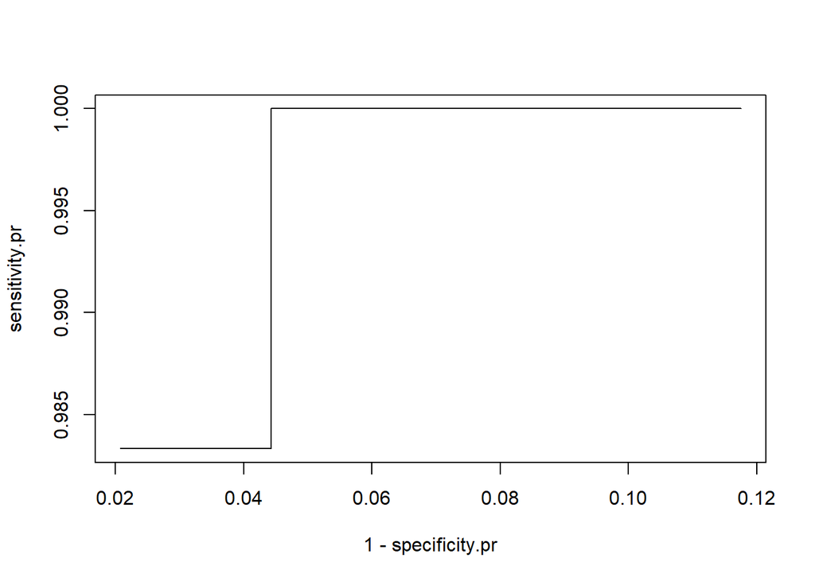

```r
threshF<-seq(0.01,0.999,0.01)
sensitivity.pr<-specificity.pr<-rep(NA,length(threshF))
for(j in seq (along=threshF)){
pp.pr<-ifelse(FAAlog_R_wsa.pr$predprob.pr< threshF[j],"no","yes")
xx.pr<-xtabs(~risky.landing+pp.pr,FAAlog_R_wsa.pr)
specificity.pr[j]<-xx.pr[1,1]/(xx.pr[1,1]+xx.pr[1,2])
sensitivity.pr[j]<-xx.pr[2,2]/(xx.pr[2,1]+xx.pr[2,2])
}
plot(1-specificity.pr,sensitivity.pr,type="l")
```

```r
#cll
linpred.cll<-predict(lmod.s_ahsg_cloglog) # Linear predictor
predprob.cll<-predict(lmod.s_ahsg_cloglog,type ="response") #predicted probabilities
predout.cll<-(ifelse(predprob.cll<0.5,"no","yes")) ### Predicted outcomes using 0.5 as the threshold
FAAlog_R_wsa.cll<-data.frame(FAAlog,predprob.cll,predout.cll)
xtabs(~risky.landing+predout.cll,FAAlog_R_wsa.cll)
```

```
##              predout.cll
## risky.landing  no yes
##             0 685  38
##             1   0  60
```

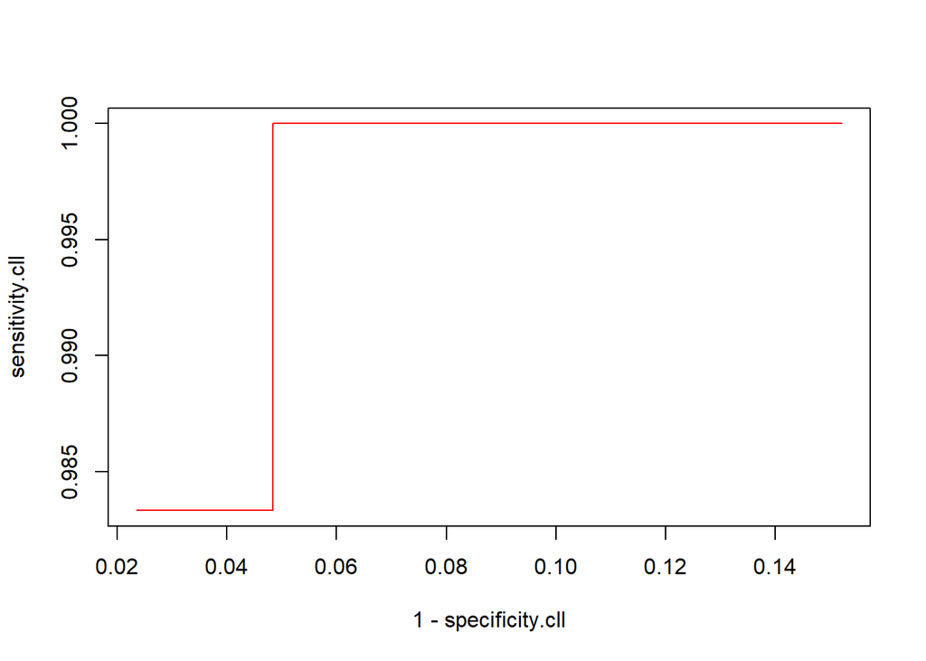

```r
threshF<-seq(0.01,0.999,0.01)
sensitivity.cll<-specificity.cll<-rep(NA,length(threshF))
for(j in seq (along=threshF)){
pp.cll<-ifelse(FAAlog_R_wsa.cll$predprob.cll< threshF[j],"no","yes")
xx.cll<-xtabs(~risky.landing+pp.cll,FAAlog_R_wsa.cll)
specificity.cll[j]<-xx.cll[1,1]/(xx.cll[1,1]+xx.cll[1,2])
sensitivity.cll[j]<-xx.cll[2,2]/(xx.cll[2,1]+xx.cll[2,2])
}
plot(1-specificity.cll,sensitivity.cll,col="Red",type="l")
```

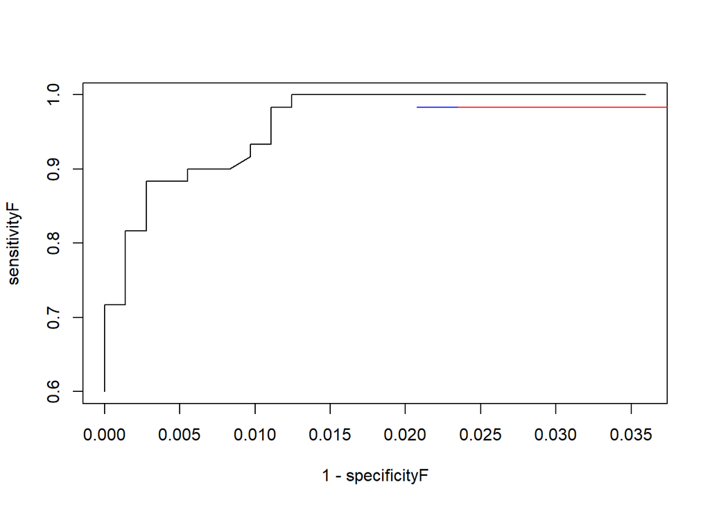

```r
plot(1-specificityF,sensitivityF,type="l")
lines(1-specificity.pr,sensitivity.pr,col="Blue")
lines(1-specificity.cll,sensitivity.cll,col="Red")
```

**Step 16.** Using each model to identify the top 5 risky landings. Do they point to the same flights?

```r
dfc<-data.frame(predval)
dfc <- mutate(dfc, id = rownames(dfc))
FAA_U_RmvNA<- mutate(FAA_U_RmvNA, id = rownames(FAA_U_RmvNA))

head(arrange(dfc,logit),5)#5,7,8,10,11
```

```
##          logit       probit      cloglog id
## 1 2.220446e-16 2.220446e-16 8.322862e-11  5
## 2 2.220446e-16 2.220446e-16 8.654803e-13  7
## 3 2.220446e-16 2.220446e-16 2.117752e-12  8
## 4 2.220446e-16 2.220446e-16 5.111611e-10 10
## 5 2.220446e-16 2.220446e-16 1.792280e-11 11
```

```r
head(arrange(dfc,probit),5)#3,5,6,7,8
```

```
##          logit       probit      cloglog id
## 1 2.649443e-12 2.220446e-16 8.265371e-09  3
## 2 2.220446e-16 2.220446e-16 8.322862e-11  5
## 3 1.323259e-08 2.220446e-16 2.878625e-06  6
## 4 2.220446e-16 2.220446e-16 8.654803e-13  7
## 5 2.220446e-16 2.220446e-16 2.117752e-12  8
```

```r
head(arrange(dfc,cloglog),5)#89,105,197,238,342
```

```
##          logit       probit      cloglog  id
## 1 2.220446e-16 2.220446e-16 2.220446e-16  89
## 2 2.220446e-16 2.220446e-16 2.220446e-16 105
## 3 2.220446e-16 2.220446e-16 2.220446e-16 197
## 4 2.220446e-16 2.220446e-16 2.220446e-16 238
## 5 2.220446e-16 2.220446e-16 2.220446e-16 342
```

```r
head(arrange(dfc,desc(logit)),5)#1
```

```
##   logit probit cloglog  id
## 1     1      1       1  64
## 2     1      1       1 364
## 3     1      1       1 309
## 4     1      1       1 136
## 5     1      1       1 178
```

```r
head(arrange(dfc,desc(probit)),5)#1
```

```
##       logit probit cloglog id
## 1 1.0000000      1       1 19
## 2 0.9999999      1       1 29
## 3 1.0000000      1       1 30
## 4 1.0000000      1       1 56
## 5 1.0000000      1       1 64
```

```r
head(arrange(dfc,desc(cloglog)),5)#1
```

```
##       logit    probit cloglog id
## 1 0.9996897 0.9999947       1  1
## 2 0.9998698 0.9999993       1 18
## 3 1.0000000 1.0000000       1 19
## 4 0.9999999 1.0000000       1 29
## 5 1.0000000 1.0000000       1 30
```

```r
head(arrange(dfc,desc(logit),desc(probit),desc(cloglog)),50)#1
```

```
##        logit    probit cloglog  id
## 1  1.0000000 1.0000000       1  64
## 2  1.0000000 1.0000000       1 364
## 3  1.0000000 1.0000000       1 309
## 4  1.0000000 1.0000000       1 136
## 5  1.0000000 1.0000000       1 178
## 6  1.0000000 1.0000000       1 410
## 7  1.0000000 1.0000000       1 389
## 8  1.0000000 1.0000000       1 181
## 9  1.0000000 1.0000000       1  56
## 10 1.0000000 1.0000000       1 385
## 11 1.0000000 1.0000000       1 645
## 12 1.0000000 1.0000000       1  19
## 13 1.0000000 1.0000000       1 269
## 14 1.0000000 1.0000000       1 341
```

[output cut: 36 more lines]

```r
FAA_U_RmvNA%>%filter(id %in% c(64,364,309,136,178,410))#yes top 5 are same
```

```
## # A tibble: 6 x 11
##   aircraft duration no_pasg speed_ground speed_air height pitch distance
##   <chr>       <dbl>   <dbl>        <dbl>     <dbl>  <dbl> <dbl>    <dbl>
## 1 boeing      162.       72         129.      128.   33.9  4.14    5382.
## 2 boeing      209.       58         125.      126.   40.1  4.65    5147.
## 3 boeing      198.       68         127.      128.   23.8  2.99    5031.
## 4 boeing      155.       67         129.      128.   24.0  5.15    5058.
## 5 boeing       63.3      52         133.      133.   18.2  4.11    5343.
## 6 airbus      132.       60         131.      131.   28.3  3.66    4896.
## # ... with 3 more variables: long.landing <dbl>, risky.landing <dbl>,
## #   id <chr>
```

```r
head(FAA_U_RmvNA,50)
```

```
## # A tibble: 50 x 11
##    aircraft duration no_pasg speed_ground speed_air height pitch distance
##    <chr>       <dbl>   <dbl>        <dbl>     <dbl>  <dbl> <dbl>    <dbl>
##  1 boeing       98.5      53        108.       109.   27.4  4.04    3370.
##  2 boeing      126.       69        102.       103.   27.8  4.12    2988.
##  3 boeing      112.       61         71.1       NA    18.6  4.43    1145.
##  4 boeing      197.       56         85.8       NA    30.7  3.88    1664.
##  5 boeing       90.1      70         59.9       NA    32.4  4.03    1050.
##  6 boeing      138.       55         75.0       NA    41.2  4.20    1627.
##  7 boeing       73.0      54         54.4       NA    24.0  3.84     805.
##  8 boeing       52.9      57         57.1       NA    19.4  4.64     574.
##  9 boeing      156.       61         85.4       NA    35.4  4.23    1699.
## 10 boeing      177.       56         61.8       NA    36.7  4.18    1138.
## # ... with 40 more rows, and 3 more variables: long.landing <dbl>,
## #   risky.landing <dbl>, id <chr>
```

If we observe the top 50 observations:

we notice that cloglog have 1 probability for more number of top line itmes Logit values tend to fall below 1 sooner that the values of probit.

This is very much inline to theoratical understanding of the concept of these functions.

### 5.2 Confidence Interval

**Step 17.** Use the probit model and hazard model to make prediction for the flight described in Step 13. Report the predicted probability as well as its 95% confidence interval. Compare the results with that from Step 13.

```r
#probit model
predict(lmod.s_ahsg_probit,newdata=new.ind,type ="link") ### Linear predictor
```

```
##        1
## 9.321099
```

```r
predict(lmod.s_ahsg_probit,newdata= new.ind,type ="response") ### Probability
```

```
## 1
## 1
```

```r
predict(lmod.s_ahsg_probit,newdata=new.ind,type ="link",se=T) ### Linear predictor
```

```
## $fit
##        1
## 9.321099
##
## $se.fit
## [1] 1.70394
##
## $residual.scale
## [1] 1
```

```r
round(ilogit(c(9.321099+1.96*1.70394,9.321099+1.96*1.70394)),5 ) ### Confidence interval
```

```
## [1] 1 1
```

```r
predict(lmod.s_ahsg_probit,newdata= new.ind,type ="response",se=T) ### Probability
```

```
## $fit
## 1
## 1
##
## $se.fit
##            1
## 3.783508e-16
##
## $residual.scale
## [1] 1
```

```r
round(c(1+1.96*3.783508e-16,1-1.96*3.783508e-16), 5 ) ### Confidence interval
```

```
## [1] 1 1
```

```r
#cll model
predict(lmod.s_ahsg_cloglog,newdata=new.ind,type ="link") ### Linear predictor
```

```
##        1
## 11.10962
```

```r
predict(lmod.s_ahsg_cloglog,newdata= new.ind,type ="response") ### Probability
```

```
## 1
## 1
```

```r
### Predict the value with its standard error
predict(lmod.s_ahsg_cloglog,newdata=new.ind,type ="link",se=T) ### Linear predictor
```

```
## $fit
##        1
## 11.10962
##
## $se.fit
## [1] 1.958174
##
## $residual.scale
## [1] 1
```

```r
round(ilogit(c( 11.10962+1.96*1.958174,11.10962+1.96*1.958174)),5 ) ### Confidence interval
```

```
## [1] 1 1
```

```r
predict(lmod.s_ahsg_cloglog,newdata= new.ind,type ="response",se=T) ### Probability
```

```
## $fit
## 1
## 1
##
## $se.fit
##            1
## 4.348019e-16
##
## $residual.scale
## [1] 1
```

```r
round(c(1+1.96*4.348019e-16,1-1.96*4.348019e-16), 5 ) ### Confidence interval
```

```
## [1] 1 1
```

We observe that confidence Interval is 1,1 which is an indicator of better prediction ability of our selected model

## 6.0 Conclusion

Is logit better than probit, or vice versa? Both methods will yield similar (though not identical) inferences. Logit - also known as logistic regression - is more popular in health sciences like epidemiology partly because coefficients can be interpreted in terms of odds ratios. Probit models can be generalized to account for non-constant error variances in more advanced econometric settings (known as heteroskedastic probit models) and hence are used in some contexts by economists and political scientists. If these more advanced applications are not of relevance, than it does not matter which method you choose to go with.